# Nora Master Project Data Analysis Notebook

```r
survey_q33_correct <- survey_q33_contingency[5,]
survey_q33_group_total <- colSums(survey_q33_contingency)
prop.test(survey_q33_correct, survey_q33_group_total)
```

```
##
##  4-sample test for equality of proportions without continuity correction
##
## data:  survey_q33_correct out of survey_q33_group_total
## X-squared = 2.0053, df = 3, p-value = 0.5713
## alternative hypothesis: two.sided
## sample estimates:
##    prop 1    prop 2    prop 3    prop 4
## 0.4067797 0.3606557 0.2878788 0.3606557
```

Plot probability of higher than 3% (proportion bar plot across different groups)

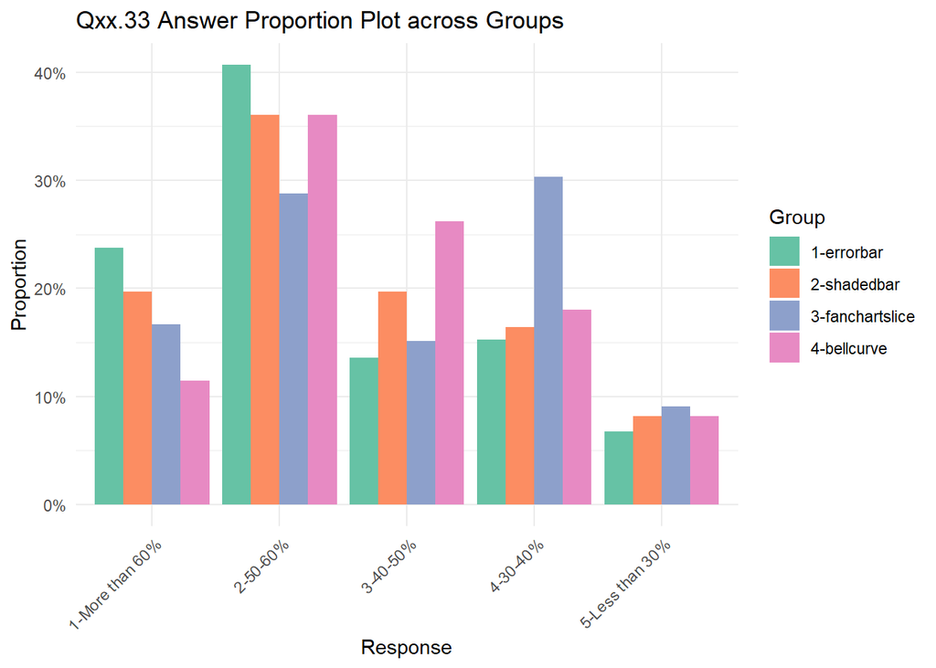

```r
survey_q33_prop  <- as.data.frame(survey_q33_contingency)
# rename columns
names(survey_q33_prop) <- c("Qxx.33", "Group", "Count")
# add a labelled column
survey_q33_prop <- survey_q33_prop %>%
  mutate(Qxx.33_label = case_when(
    Qxx.33 == "1" ~ "1-More than 60%",
    Qxx.33 == "2" ~ "3-40-50%",
    Qxx.33 == "3" ~ "4-30-40%",
    Qxx.33 == "4" ~ "5-Less than 30%",
    Qxx.33 == "5" ~ "2-50-60%"
  ))
# calculate proportions within each group
survey_q33_prop <- survey_q33_prop %>%
  group_by(Group) %>%
  mutate(Proportion = Count / sum(Count))
ggplot(survey_q33_prop, aes(x = as.factor(`Qxx.33_label`), y = Proportion, fill = Group)) + geom_col(position = "dodge") +
  # facet_wrap(~Group)+
  labs(
    title = "Qxx.33 Answer Proportion Plot across Groups",
    x = "Response",
    y = "Proportion"
  ) +
   scale_fill_brewer(palette = "Set2")+
  scale_y_continuous(labels = scales::percent_format(accuracy = 1)) +
  theme_minimal()+
  theme(axis.text.x = element_text(angle = 45, hjust = 1))
```

Plot the histogram including all participants

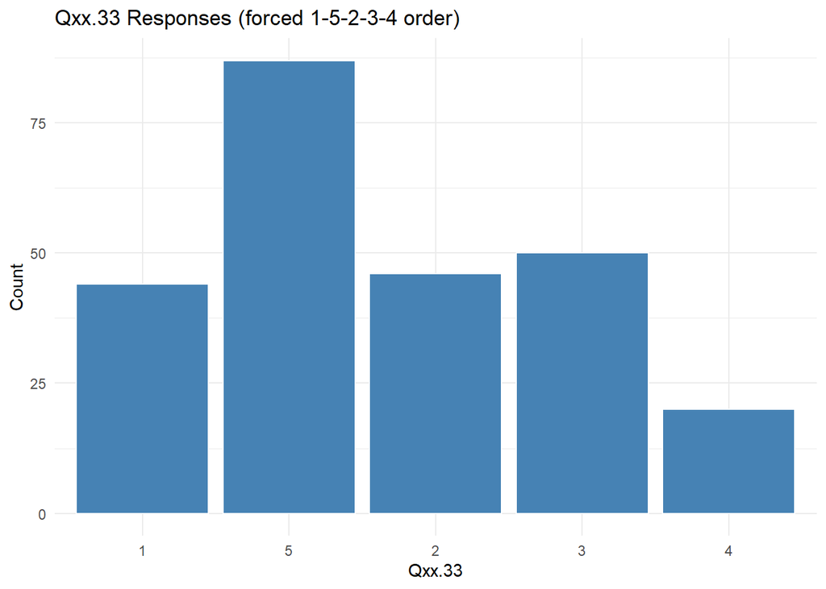

```r
# force order for graph
survey_q33 <- survey_q33 %>%
  mutate(
    q33_value_re = factor(
      q33_value,
      levels = c(1, 5, 2, 3, 4)
    )
  )
# histogram including all participants
ggplot(survey_q33, aes(x = q33_value_re)) +
  geom_bar(fill = "steelblue", color = "white") +
  labs(
    title = "Qxx.33 Responses (forced 1-5-2-3-4 order)",
    x     = "Qxx.33",
    y     = "Count"
  ) +
  theme_minimal()
```

```r
# combine data from different groups
survey_q34 <- data.frame()
survey_q34_list <- list("Q6.34_1","Q8.34_1", "Q10.34_1", "Q12.34_1")
for (i in seq_along(skewed_group_list)) {
  df <- skewed_group_list[[i]]
  col <- survey_q34_list[[i]]
  temp_table <- df[, c(col, "group")]
  names(temp_table) <- c("q34_value", "group")
  survey_q34 <- rbind(survey_q34, temp_table)
}
survey_q34$q34_value <- as.numeric(survey_q34$q34_value)
```

Summary Table

```r
survey_q34_summary <- survey_q34 %>%
  group_by(group) %>%
  summarise(
    median = median(q34_value, na.rm = TRUE),
    IQR    = IQR(q34_value,   na.rm = TRUE),  # same as Q3 − Q1
    Q1     = quantile(q34_value, 0.25, na.rm = TRUE),
    Q3     = quantile(q34_value, 0.75, na.rm = TRUE),
    mean   = mean(q34_value, na.rm = TRUE)
  )
print(survey_q34_summary)
```

```
## # A tibble: 4 × 6
##   group           median   IQR    Q1    Q3  mean
##   <chr>            <dbl> <dbl> <dbl> <dbl> <dbl>
## 1 1-errorbar          13     1    12    13  12.7
## 2 2-shadedbar         13     1    12    13  12.8
## 3 3-fanchartslice     12     1    12    13  12.3
## 4 4-bellcurve         12     1    12    13  12.4
```

KW test

```r
# check normality --> the data is not normally distributed
# shapiro.test(survey_q34$q34_value)

# run Kruskal-Wallis test
kruskal_test <- kruskal.test(q34_value ~ group, data = survey_q34)
print(kruskal_test)
```

```
##
##  Kruskal-Wallis rank sum test
##
## data:  q34_value by group
## Kruskal-Wallis chi-squared = 5.5506, df = 3, p-value = 0.1356
```

Plot the distribution of different groups

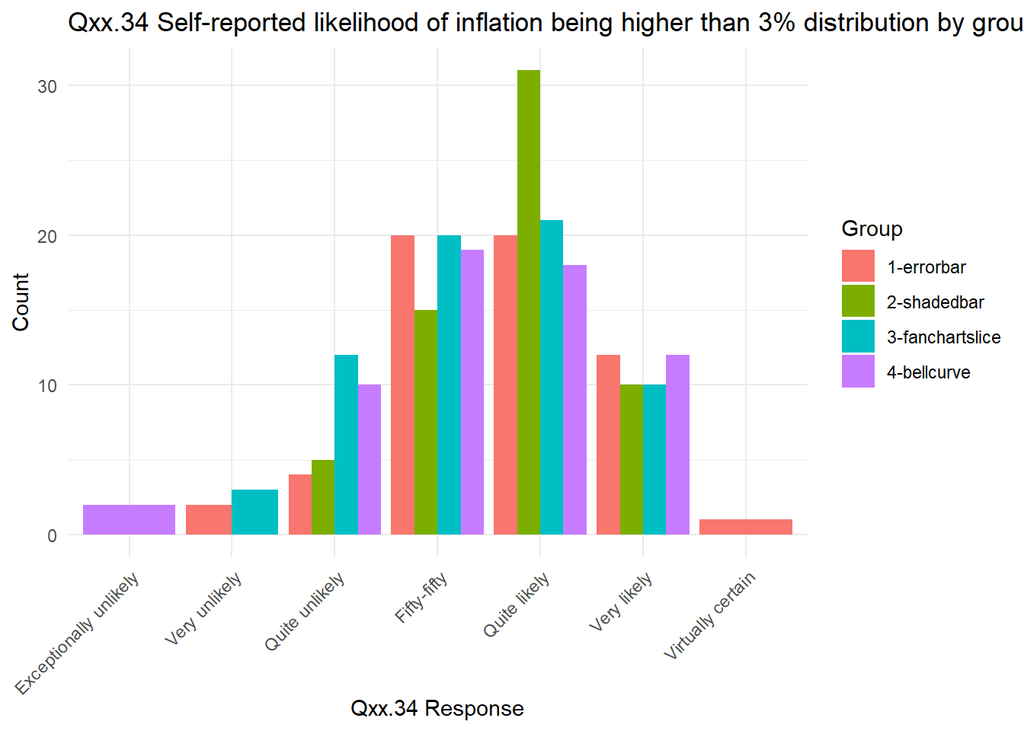

```r
# Grouped bar-style histogram
ggplot(survey_q34, aes(x = factor(q34_value), fill = factor(group))) +
  geom_bar(position = "dodge") +
  # facet_wrap(~ group) +
  # add labels
  scale_x_discrete(labels=likelihood_labels) +
  labs(
    title = "Qxx.34 Self-reported likelihood of inflation being higher than 3% distribution by group",
    x = "Qxx.34 Response",
    y = "Count",
    fill = "Group"
  ) +
  theme_minimal() +
  theme(axis.text.x = element_text(angle = 45, hjust = 1))
```

Plot bar chart including all participants

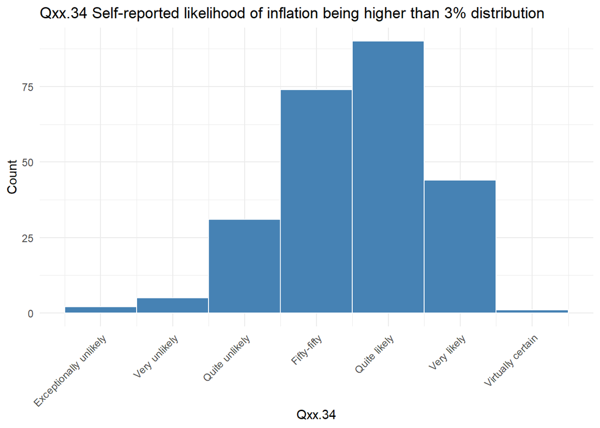

```r
# histogram including all participants
ggplot(survey_q34, aes(x = q34_value)) +
  geom_histogram(binwidth = 1, fill = "steelblue", color = "white") +
  # facet_wrap(~ group) +
  labs(title = "Qxx.34 Self-reported likelihood of inflation being higher than 3% distribution",
       x = "Qxx.34",
       y = "Count") +
  scale_x_continuous(breaks = as.numeric(names(likelihood_labels)),
                     labels = likelihood_labels) +
  theme_minimal() +
  theme(axis.text.x = element_text(angle = 45, hjust = 1))
```

## Qxx.35 Ranking for 26Q3 Based on the inflation forecast provided, please rank the following inflation rates from most likely to least likely to occur: 1.1%, 2.6%, 3.3% and 4.1%. - 4.1%  
*Lower mean rank = more preferred*  
Method: Mean Rank

```r
q35_prefixes <- list("Q6.35", "Q8.35", "Q10.35", "Q12.35")
rank_summary_skewed <- data.frame(
  Item = c("1.1%", "2.6%", "3.3%", "4.1%")
)
survey_q35 <- data.frame()
for (i in seq_along(skewed_group_list)) {
  group_name <- names(skewed_group_list)[i]
  df <- skewed_group_list[[i]]
  q_cols <- paste0(q35_prefixes[[i]], "_", 5:8)
  temp_table <- df[, c(q_cols, "group")]
  # combine the data
  names(temp_table) <- c("Qxx.35_5", "Qxx.35_6", "Qxx.35_7", "Qxx.35_8", "group")
  temp_table[, c("Qxx.35_5", "Qxx.35_6", "Qxx.35_7", "Qxx.35_8")] <-
    lapply(temp_table[, c("Qxx.35_5", "Qxx.35_6", "Qxx.35_7", "Qxx.35_8")], as.numeric)
  survey_q35 <- rbind(survey_q35, temp_table)

  # mean rank
  df <- as.data.frame(lapply(df[,q_cols], as.numeric))
  mean_rank <- colMeans(df, na.rm = TRUE)
  rank_summary_skewed[[group_name]] <- mean_rank
}
# overall means
overall_means <- rowMeans(rank_summary_skewed[, -1], na.rm = TRUE)
rank_summary_skewed <- cbind(rank_summary_skewed, Overall = overall_means)
# correct answer
survey_q35_correct_prop <- survey_q35 %>%
  group_by(group) %>%
  summarise(
    total = n(),
    correct = sum(
      Qxx.35_5 == 4 & Qxx.35_6 == 1 & Qxx.35_7 == 2 & Qxx.35_8 == 3,
      na.rm = TRUE
    ),
    proportion_correct = correct / total,
    .groups = "drop"
  )
```

proportion test

```r
prop.test(
  x = survey_q35_correct_prop$correct,
  n = survey_q35_correct_prop$total
)
```

```
##
##  4-sample test for equality of proportions without continuity correction
##
## data:  survey_q35_correct_prop$correct out of survey_q35_correct_prop$total
## X-squared = 4.3257, df = 3, p-value = 0.2284
## alternative hypothesis: two.sided
## sample estimates:
##    prop 1    prop 2    prop 3    prop 4
## 0.4237288 0.2622951 0.3939394 0.4098361
```

Visualisation Proportion

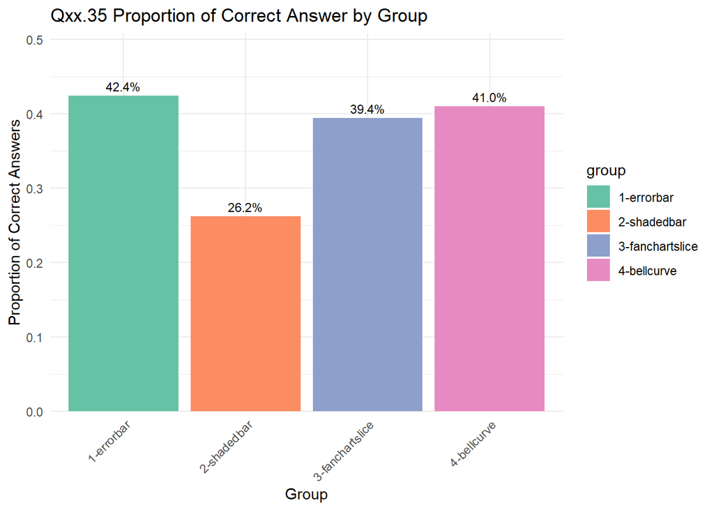

```r
ggplot(survey_q35_correct_prop, aes(x = group, y = proportion_correct, fill = group)) +
  geom_bar(stat = "identity") +
  geom_text(aes(label = scales::percent(proportion_correct, accuracy = 0.1)),
            vjust = -0.5, size = 3) +
  labs(
    title = "Qxx.35 Proportion of Correct Answer by Group",
    x = "Group",
    y = "Proportion of Correct Answers"
  ) +
    scale_y_continuous(
    expand = expansion(mult = c(0, 0.2))
  ) +
  scale_fill_brewer(palette = "Set2") +
  theme_minimal() +
  theme(axis.text.x = element_text(angle = 45, hjust = 1))
```

Visualisation Ranking

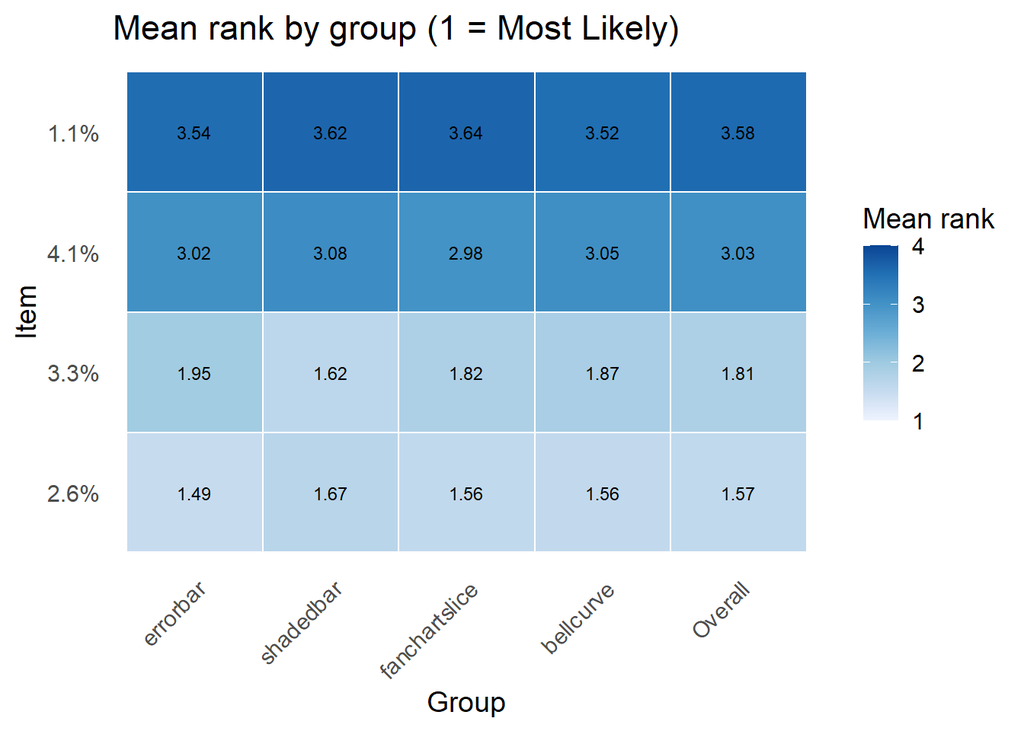

```r
df_long_skewed <- rank_summary_skewed %>%
  pivot_longer(-Item, names_to = "Group", values_to = "MeanRank") %>%
  mutate(
    # Order items by their overall best rank (smallest = best)
    Item  = factor(Item, levels = rank_summary_skewed %>% arrange(Overall) %>% pull(Item)),
    # Keep groups in the order they appear in the data-frame
    Group = factor(Group, levels = names(rank_summary_skewed)[-1])
  )

ggplot(df_long_skewed, aes(Group, Item, fill = MeanRank)) +
  geom_tile(colour = "white", linewidth = .4) +
  geom_text(aes(label = round(MeanRank, 2)), size = 3) +
  scale_fill_distiller(palette = "Blues", direction = 1,
                       name = "Mean rank", limits = c(1, 4),
                       breaks = 1:4) +
  labs(title = "Mean rank by group (1 = Most Likely)") +
  theme_minimal(base_size = 14) +
  theme(panel.grid = element_blank(),
        axis.text.x = element_text(angle = 45, hjust = 1))
```

## Qxx.36 Deviation from central estimate

Based on the inflation forecast provided, do you think there is a higher risk of inflation exceeding the central estimate or of being less than this central estimate?  
Definitive Correct Answer - 1  
Variable: categorical  
Method: contingency table & proportion test  
**Result: There is no statistical difference across group. 68% of respondents can understand there is bigger upside risk.**

```r
# combine data from different groups
survey_q36 <- data.frame()
survey_q36_list <- list("Q6.36","Q8.36", "Q10.36", "Q12.36")
for (i in seq_along(skewed_group_list)) {
  df <- skewed_group_list[[i]]
  col <- survey_q36_list[[i]]
  temp_table <- df[, c(col, "group")]
  names(temp_table) <- c("q36_value", "group")
  survey_q36 <- rbind(survey_q36, temp_table)
}
survey_q36$q36_value <- as.numeric(survey_q36$q36_value)
```

Contingency table

```r
survey_q36_contingency <- table(survey_q36$q36_value, survey_q36$group)
print(survey_q36_contingency)
```

```
##
##     1-errorbar 2-shadedbar 3-fanchartslice 4-bellcurve
##   1         38          42              47          41
##   2          5           1               7           6
##   3         16          18              12          14
```

```r
chisq_result <- chisq.test(survey_q36_contingency)
print(chisq_result)
```

```
##
##  Pearson's Chi-squared test
##
## data:  survey_q36_contingency
## X-squared = 6.2063, df = 6, p-value = 0.4005
```

Test the proportion of correct answer

```r
survey_q36_correct <- survey_q36_contingency[1,]
survey_q36_group_total <- colSums(survey_q36_contingency)
prop.test(survey_q36_correct, survey_q36_group_total)
```

```
##
##  4-sample test for equality of proportions without continuity correction
##
## data:  survey_q36_correct out of survey_q36_group_total
## X-squared = 0.70091, df = 3, p-value = 0.873
## alternative hypothesis: two.sided
## sample estimates:
##    prop 1    prop 2    prop 3    prop 4
## 0.6440678 0.6885246 0.7121212 0.6721311
```

Plot proportion bar plot across different groups

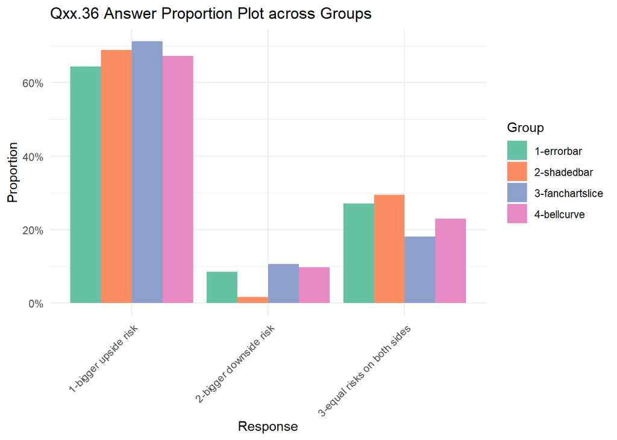

```r
survey_q36_prop  <- as.data.frame(survey_q36_contingency)
# rename columns
names(survey_q36_prop) <- c("Qxx.36", "Group", "Count")
# add a labelled column
survey_q36_prop <- survey_q36_prop %>%
  mutate(Qxx.36_label = case_when(
    Qxx.36 == "1" ~ "1-bigger upside risk",
    Qxx.36 == "2" ~ "2-bigger downside risk",
    Qxx.36 == "3" ~ "3-equal risks on both sides"
  ))
# calculate proportions within each group
survey_q36_prop <- survey_q36_prop %>%
  group_by(Group) %>%
  mutate(Proportion = Count / sum(Count))
ggplot(survey_q36_prop, aes(x = as.factor(`Qxx.36_label`), y = Proportion, fill = Group)) + geom_col(position = "dodge") +
  # facet_wrap(~Group)+
  labs(
    title = "Qxx.36 Answer Proportion Plot across Groups",
    x = "Response",
    y = "Proportion"
  ) +
   scale_fill_brewer(palette = "Set2")+
  scale_y_continuous(labels = scales::percent_format(accuracy = 1)) +
  theme_minimal()+
  theme(axis.text.x = element_text(angle = 45, hjust = 1))
```

Plot the histogram including all participants

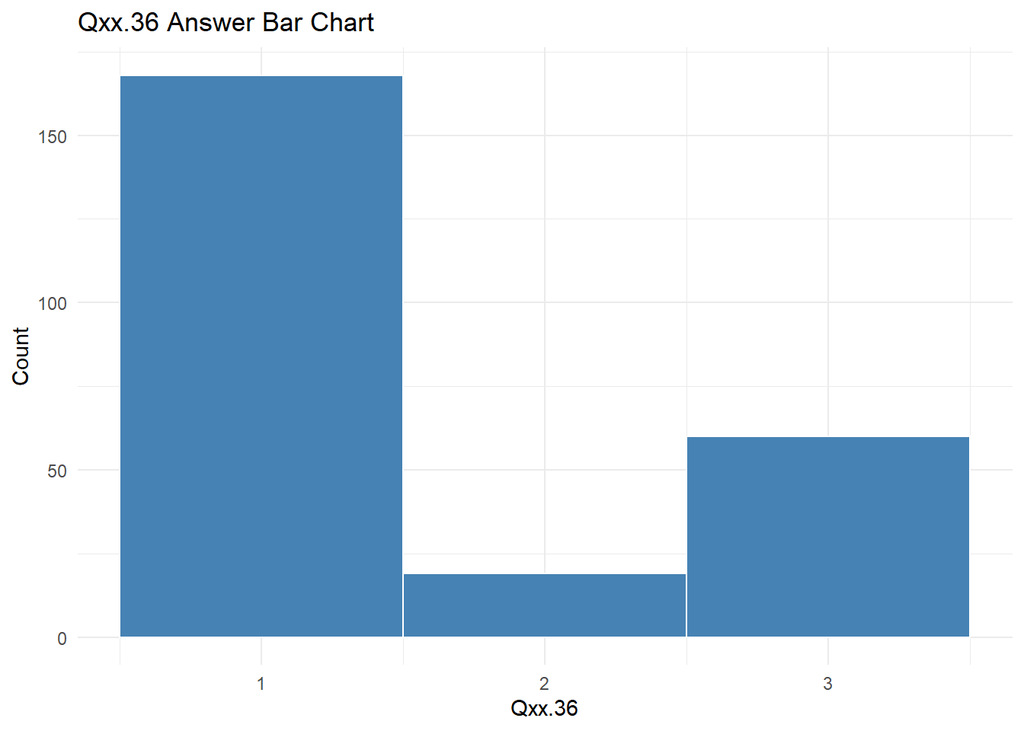

```r
# histogram including all participants
ggplot(survey_q36, aes(x = q36_value)) +
  geom_histogram(binwidth = 1, fill = "steelblue", color = "white") +
  # facet_wrap(~ group) +
  labs(title = "Qxx.36 Answer Bar Chart",
       x = "Qxx.36",
       y = "Count") +
  scale_x_continuous(breaks = seq(0, max(survey_q36$q36_value, na.rm = TRUE), by = 1)) +
  theme_minimal()
```

## ? Qxx.37 Risk of ending outside

If the actual inflation ends up outside the black line, which side is more likely, based on the uncertainty depicted in the graph?  
Definitive Correct Answer - 1  
Variable: categorical  
Method: contingency table & proportion test  
**Result: 63% respondents think if the actual inflation ends up outside, it’s more likely to be on the upper side.**

```r
# combine data from different groups
survey_q37 <- data.frame()
survey_q37_list <- list("Q6.37","Q8.37", "Q10.37", "Q12.37")
for (i in seq_along(skewed_group_list)) {
  df <- skewed_group_list[[i]]
  col <- survey_q37_list[[i]]
  temp_table <- df[, c(col, "group")]
  names(temp_table) <- c("q37_value", "group")
  survey_q37 <- rbind(survey_q37, temp_table)
}
survey_q37$q37_value <- as.numeric(survey_q37$q37_value)
```

Contingency table

```r
survey_q37_contingency <- table(survey_q37$q37_value, survey_q37$group)
print(survey_q37_contingency)
```

```
##
##     1-errorbar 2-shadedbar 3-fanchartslice 4-bellcurve
##   1         33          35              51          37
##   2         10          11               5           7
##   3         16          15              10          17
```

```r
# chisq_result <- chisq.test(survey_q37_contingency)
# print(chisq_result)

# Test the proportion of correct answer
survey_q37_correct <- survey_q37_contingency[1,]
survey_q37_group_total <- colSums(survey_q37_contingency)
prop.test(survey_q37_correct, survey_q37_group_total)
```

```
##
##  4-sample test for equality of proportions without continuity correction
##
## data:  survey_q37_correct out of survey_q37_group_total
## X-squared = 8.015, df = 3, p-value = 0.0457
## alternative hypothesis: two.sided
## sample estimates:
##    prop 1    prop 2    prop 3    prop 4
## 0.5593220 0.5737705 0.7727273 0.6065574
```

```r
# pairwise proportion test
pairwise.prop.test(
  x = survey_q37_contingency[1,],
  n = colSums(survey_q37_contingency),
  p.adjust.method = "bonferroni" # or "holm", "BH"
)
```

```
##
##  Pairwise comparisons using Pairwise comparison of proportions
##
## data:  survey_q37_contingency[1, ] out of colSums(survey_q37_contingency)
##
##                 1-errorbar 2-shadedbar 3-fanchartslice
## 2-shadedbar     1.00       -           -
## 3-fanchartslice 0.11       0.16        -
## 4-bellcurve     1.00       1.00        0.40
##
## P value adjustment method: bonferroni
```

Plot proportion bar plot across different groups

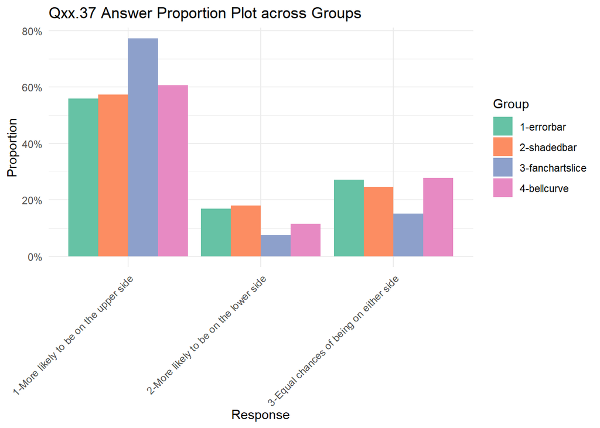

```r
survey_q37_prop  <- as.data.frame(survey_q37_contingency)
# rename columns
names(survey_q37_prop) <- c("Qxx.37", "Group", "Count")
# add a labelled column
survey_q37_prop <- survey_q37_prop %>%
  mutate(Qxx.37_label = case_when(
    Qxx.37 == "1" ~ "1-More likely to be on the upper side",
    Qxx.37 == "2" ~ "2-More likely to be on the lower side",
    Qxx.37 == "3" ~ "3-Equal chances of being on either side"
  ))
# calculate proportions within each group
survey_q37_prop <- survey_q37_prop %>%
  group_by(Group) %>%
  mutate(Proportion = Count / sum(Count))
ggplot(survey_q37_prop, aes(x = as.factor(`Qxx.37_label`), y = Proportion, fill = Group)) + geom_col(position = "dodge") +
  # facet_wrap(~Group)+
  labs(
    title = "Qxx.37 Answer Proportion Plot across Groups",
    x = "Response",
    y = "Proportion"
  ) +
   scale_fill_brewer(palette = "Set2")+
  scale_y_continuous(labels = scales::percent_format(accuracy = 1)) +
  theme_minimal()+
  theme(axis.text.x = element_text(angle = 45, hjust = 1))
```

Plot the histogram including all participants

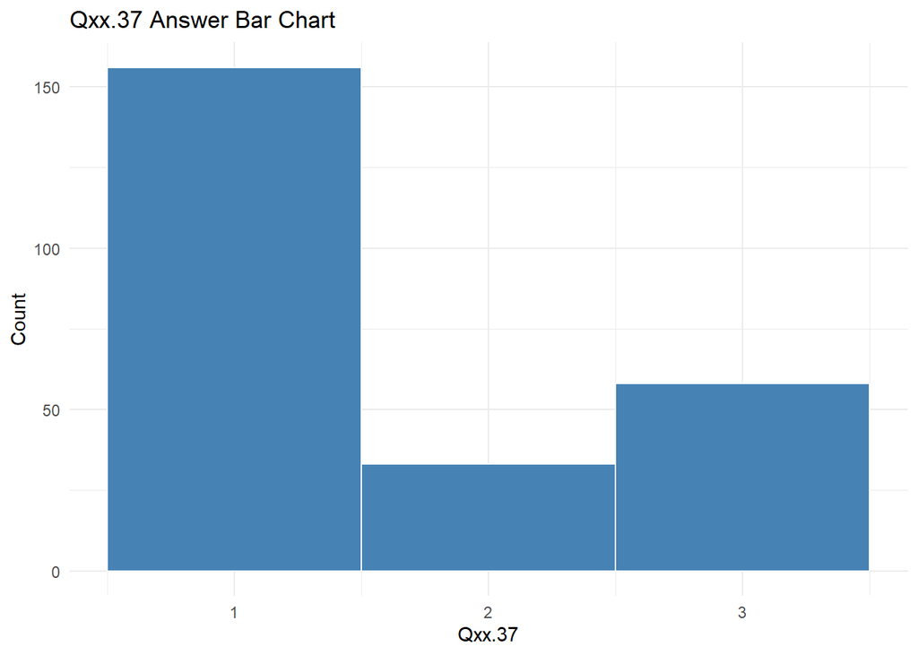

```r
# histogram including all participants
ggplot(survey_q37, aes(x = q37_value)) +
  geom_histogram(binwidth = 1, fill = "steelblue", color = "white") +
  # facet_wrap(~ group) +
  labs(title = "Qxx.37 Answer Bar Chart",
       x = "Qxx.37",
       y = "Count") +
  scale_x_continuous(breaks = seq(0, max(survey_q37$q37_value, na.rm = TRUE), by = 1)) +
  theme_minimal()
```

# Decision-making

## D.3 Investment Decision

Which bond would you choose to invest in?  
Variable: categorical  
Method: contingency table & proportion test  
**Result: Fail to reject the null hypothesis.**

```r
# combine data from different groups
survey_d3 <- data.frame()
survey_d3_list <- list("Q5.3","Q7.3", "Q9.3", "Q11.3", "Q13.3")
for (i in seq_along(group_list)) {
  df <- group_list[[i]]
  col <- survey_d3_list[[i]]
  temp_table <- df[, c(col, "group","treatment")]
  names(temp_table) <- c("d3_value", "group", "treatment")
  survey_d3 <- rbind(survey_d3, temp_table)
}
survey_d3$d3_value <- as.numeric(survey_d3$d3_value)
```

Contingency table

```r
survey_d3_contingency <- table(survey_d3$d3_value, survey_d3$group)
print(survey_d3_contingency)
```

```
##
##     0-controlled 1-errorbar 2-shadedbar 3-fanchartslice 4-bellcurve
##   1           22         17          24              22          17
##   2           40         42          37              44          44
```

```r
# chi-squared test
chisq.test(survey_d3_contingency)
```

```
##
##  Pearson's Chi-squared test
##
## data:  survey_d3_contingency
## X-squared = 2.4805, df = 4, p-value = 0.6481
```

```r
# prop.test
# survey_d3_correct <- survey_d3_contingency[1,]
# survey_d3_group_total <- colSums(survey_d3_contingency)
# prop.test(survey_d3_correct, survey_d3_group_total)
```

Combine all treatment groups (p-value = 0.7548)

```r
survey_d3_contingency <- table(survey_d3$d3_value, survey_d3$treatment)
print(survey_d3_contingency)
```

```
##
##     0-controlled treatment_group
##   1           22              80
##   2           40             167
```

```r
# chi-squared test
chisq.test(survey_d3_contingency)
```

```
##
##  Pearson's Chi-squared test with Yates' continuity correction
##
## data:  survey_d3_contingency
## X-squared = 0.097553, df = 1, p-value = 0.7548
```

Plot proportion bar plot across different groups

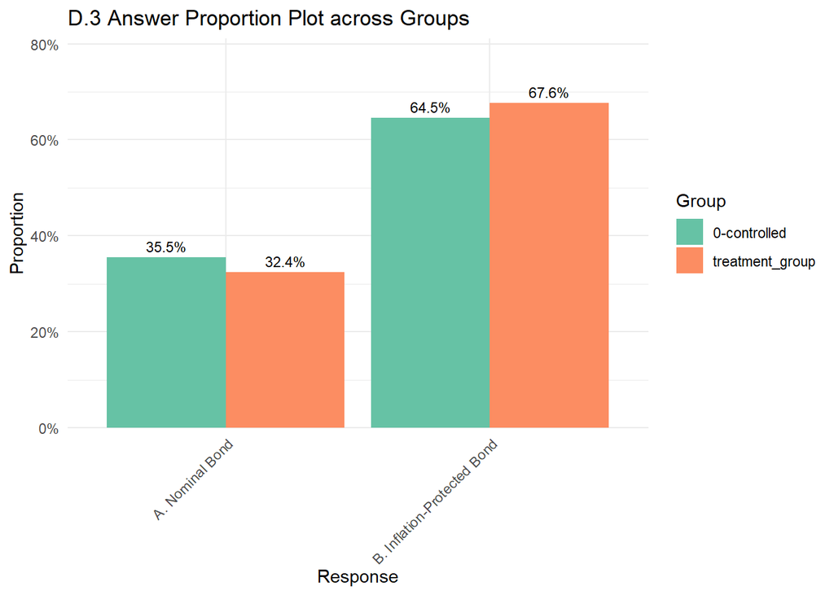

```r
survey_d3_prop  <- as.data.frame(survey_d3_contingency)
# rename columns
names(survey_d3_prop) <- c("D.3", "Group", "Count")
# add a labelled column
survey_d3_prop <- survey_d3_prop %>%
  mutate(D.3_label = case_when(
    D.3 == "1" ~ "A. Nominal Bond",
    D.3 == "2" ~ "B. Inflation-Protected Bond"
  ))
# calculate proportions within each group
survey_d3_prop <- survey_d3_prop %>%
  group_by(Group) %>%
  mutate(Proportion = Count / sum(Count))
ggplot(survey_d3_prop, aes(x = as.factor(`D.3_label`), y = Proportion, fill = Group)) + geom_col(position = "dodge") +
  # facet_wrap(~Group)+
  geom_text(aes(label = scales::percent(Proportion, accuracy = 0.1)),
            position = position_dodge(width = 0.9), vjust = -0.5, size = 3) +
  labs(
    title = "D.3 Answer Proportion Plot across Groups",
    x = "Response",
    y = "Proportion"
  ) +
   scale_fill_brewer(palette = "Set2")+
  scale_y_continuous(labels = scales::percent_format(accuracy = 1),
    expand = expansion(mult = c(0, 0.2))
  )  +
  theme_minimal()+
  theme(axis.text.x = element_text(angle = 45, hjust = 1))
```

Plot pie chart including all participants

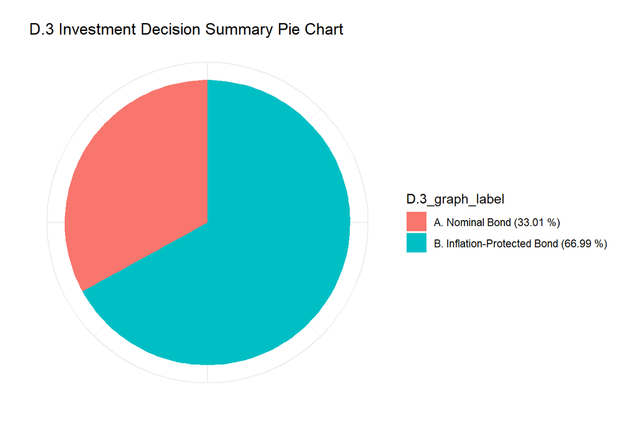

```r
survey_d3_summary <- survey_d3_prop %>%
  group_by(`D.3_label`) %>%
  summarise(total_count = sum(Count), .groups = "drop") %>%
  mutate(proportion = total_count / sum(total_count),
         `D.3_graph_label` = paste0(`D.3_label`, " (", round(proportion * 100, 2), " %)"))
ggplot(survey_d3_summary, aes(x = "",y = proportion, fill = `D.3_graph_label`)) +
  geom_col(width = 1) +
  coord_polar(theta = "y") +
  labs(title = "D.3 Investment Decision Summary Pie Chart",
       x = "",
       y = "") +
  theme_minimal() +
  theme(axis.text.x = element_blank())
```

## D.4 Confidence in decision-making On a scale of 1 to 10, where 1 means not confident at all and 10 means very confident, how confident are you in making the decision?  
*1-Not confident at all; 10-Very confident*  
Variable: continuous  
Method: ANNOVA test or KW test (depends on whether it’s normally distributed)  
**Result: Fail to reject the null hypothesis.**

```r
# combine data from different groups
survey_d4 <- data.frame()
survey_d4_list <- list("Q5.4_1","Q7.4_1", "Q9.4_1", "Q11.4_1", "Q13.4_1")
for (i in seq_along(group_list)) {
  df <- group_list[[i]]
  col <- survey_d4_list[[i]]
  temp_table <- df[, c(col, "group","treatment")]
  names(temp_table) <- c("d4_value", "group", "treatment")
  survey_d4 <- rbind(survey_d4, temp_table)
}
survey_d4$d4_value <- as.numeric(survey_d4$d4_value)
summary(survey_d4$d4_value)
```

```
##    Min. 1st Qu.  Median    Mean 3rd Qu.    Max.
##   1.000   6.000   7.000   6.896   8.000  10.000
```

Statistical test (p-value = 0.1333)

```r
# Initial Check
# summary(survey_d4$d4_value)
# check normality --> the data is not normally distributed
# shapiro.test(survey_d4$d4_value)

# run Kruskal-Wallis test
kruskal_test <- kruskal.test(d4_value ~ group, data = survey_d4)
print(kruskal_test)
```

```
##
##  Kruskal-Wallis rank sum test
##
## data:  d4_value by group
## Kruskal-Wallis chi-squared = 7.0487, df = 4, p-value = 0.1333
```

```r
# Effect size
kw_es  <- kruskal_effsize(d4_value ~ group, data = survey_d4, ci = TRUE)
print(kw_es)
```

```
## # A tibble: 1 × 7
##   .y.          n effsize conf.low conf.high method  magnitude
## * <chr>    <int>   <dbl>    <dbl>     <dbl> <chr>   <ord>
## 1 d4_value   309  0.0100  -0.0051      0.07 eta2[H] small
```

Combine all treatment groups (p-value = 0.5824)

```r
# run Kruskal-Wallis test
kruskal_test <- kruskal.test(d4_value ~ treatment, data = survey_d4)
print(kruskal_test)
```

```
##
##  Kruskal-Wallis rank sum test
##
## data:  d4_value by treatment
## Kruskal-Wallis chi-squared = 0.30241, df = 1, p-value = 0.5824
```

```r
survey_d4_test <- survey_d4 %>%
  group_by(treatment) %>%
  summarise(
    mean = mean(d4_value, na.rm = TRUE))
```

Summary statistics

```r
# Summary statistics
survey_d4_summary <- survey_d4 %>%
  group_by(group) %>%
  summarise(
    mean = mean(d4_value, na.rm = TRUE),
    median = median(d4_value, na.rm = TRUE),
    sd = sd(d4_value, na.rm = TRUE),
    IQR    = IQR(d4_value,   na.rm = TRUE),  # same as Q3 − Q1
    Q1     = quantile(d4_value, 0.25, na.rm = TRUE),
    Q3     = quantile(d4_value, 0.75, na.rm = TRUE)
  )
print(survey_d4_summary)
```

```
## # A tibble: 5 × 7
##   group            mean median    sd   IQR    Q1    Q3
##   <chr>           <dbl>  <dbl> <dbl> <dbl> <dbl> <dbl>
## 1 0-controlled     7.03      7  1.77     2     6     8
## 2 1-errorbar       7.22      8  1.70     2     6     8
## 3 2-shadedbar      7.16      7  1.69     2     6     8
## 4 3-fanchartslice  6.61      7  1.90     2     6     8
## 5 4-bellcurve      6.49      7  1.92     2     6     8
```

Plot the distribution of different groups

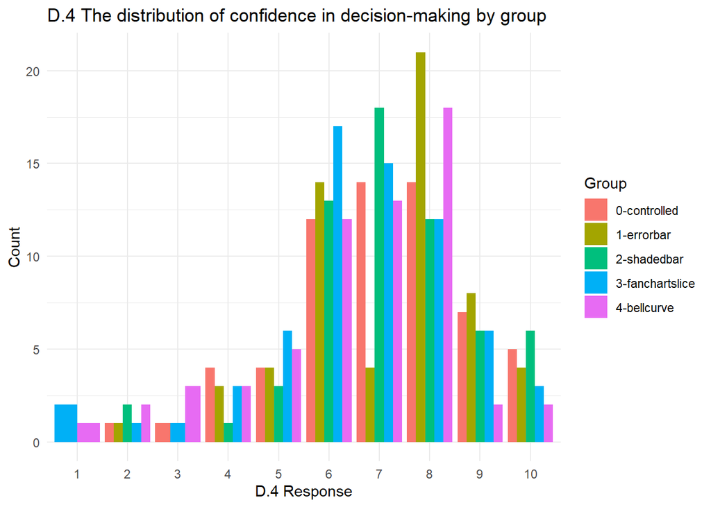

```r
# Grouped bar-style histogram
ggplot(survey_d4, aes(x = factor(d4_value), fill = factor(group))) +
  geom_bar(position = "dodge") +
  # facet_wrap(~ group) +
  labs(
    title = "D.4 The distribution of confidence in decision-making by group",
    x = "D.4 Response",
    y = "Count",
    fill = "Group"
  ) +
  theme_minimal()
```

## D.6 Considering nominal bond If the probability of inflation being low (≤ 3%) is greater than the following percentages, I would consider investing in the nominal bond:  
Variable: categorical  
Method: contingency table & chi-squared test  
**Result: Fail to reject the null hypothesis.**

```r
# combine data from different groups
survey_d6 <- data.frame()
survey_d6_list <- list("Q5.6","Q7.6", "Q9.6", "Q11.6", "Q13.6")
for (i in seq_along(group_list)) {
  df <- group_list[[i]]
  col <- survey_d6_list[[i]]
  temp_table <- df[, c(col, "group")]
  names(temp_table) <- c("d6_value", "group")
  survey_d6 <- rbind(survey_d6, temp_table)
}
survey_d6$d6_value <- as.numeric(survey_d6$d6_value)
```

Contingency table

```r
survey_d6_contingency <- table(survey_d6$d6_value, survey_d6$group)
print(survey_d6_contingency)
```

```
##
##     0-controlled 1-errorbar 2-shadedbar 3-fanchartslice 4-bellcurve
##   1            0          1           0               3           2
##   2            2          4           1               4           3
##   3            6          5           8               2           2
##   4            2          5           5               6           9
##   5           15         10           8              12          10
##   7            6          8           7              14           8
##   8            9          9           8               3          10
```